# HT4 - Arboles de desición

Stefan Quintana, Sofía Escobar, Wilfredo Gallegos

3/7/2023

[output not shown]

[output cut: 296 more lines]

[output not shown]

##Pregunta 1. Particion de los datos en dos conjuntos

Como los datos están balanceados se hizo una partición aleatoria utilizando el 70% de los datos para entrenamiento y el 30% de los datos para prueba.

```r
porcentaje<-0.7
set.seed(123)
corte <- sample(nrow(datosc),nrow(datosc)*porcentaje)
training<-datos[corte,]
test<-datos[-corte,]
```

```
##      Id MSSubClass MSZoning LotFrontage LotArea Street Alley LotShape
## 415 415         60       RL          59   11228   Pave  <NA>      IR2
## 463 463         20       RL          60    8281   Pave  <NA>      IR1
## 179 179         20       RL          63   17423   Pave  <NA>      IR1
## 526 526         20       FV          62    7500   Pave  Pave      Reg
## 195 195         20       RL          60    7180   Pave  <NA>      IR1
## 938 938         60       RL          75    9675   Pave  <NA>      Reg
##     LandContour Utilities LotConfig LandSlope Neighborhood Condition1
## 415         Lvl    AllPub   CulDSac       Gtl      SawyerW       Norm
## 463         Lvl    AllPub    Inside       Gtl       Sawyer       Norm
## 179         Lvl    AllPub   CulDSac       Gtl      StoneBr       Norm
## 526         Lvl    AllPub    Inside       Gtl      Somerst       Norm
## 195         Lvl    AllPub    Inside       Gtl      CollgCr       Norm
## 938         Lvl    AllPub    Inside       Gtl      Somerst       Norm
##     Condition2 BldgType HouseStyle OverallQual OverallCond YearBuilt
```

[output cut: 76 more lines]

```r
head(test)
```

```
##    Id MSSubClass MSZoning LotFrontage LotArea Street Alley LotShape LandContour
## 1   1         60       RL          65    8450   Pave  <NA>      Reg         Lvl
## 3   3         60       RL          68   11250   Pave  <NA>      IR1         Lvl
## 7   7         20       RL          75   10084   Pave  <NA>      Reg         Lvl
## 9   9         50       RM          51    6120   Pave  <NA>      Reg         Lvl
## 12 12         60       RL          85   11924   Pave  <NA>      IR1         Lvl
## 14 14         20       RL          91   10652   Pave  <NA>      IR1         Lvl
##    Utilities LotConfig LandSlope Neighborhood Condition1 Condition2 BldgType
## 1     AllPub    Inside       Gtl      CollgCr       Norm       Norm     1Fam
## 3     AllPub    Inside       Gtl      CollgCr       Norm       Norm     1Fam
## 7     AllPub    Inside       Gtl      Somerst       Norm       Norm     1Fam
## 9     AllPub    Inside       Gtl      OldTown     Artery       Norm     1Fam
## 12    AllPub    Inside       Gtl      NridgHt       Norm       Norm     1Fam
## 14    AllPub    Inside       Gtl      CollgCr       Norm       Norm     1Fam
##    HouseStyle OverallQual OverallCond YearBuilt YearRemodAdd RoofStyle RoofMatl
```

[output cut: 69 more lines]

##Pregunta 2. Arbol de regresión con todas las variables

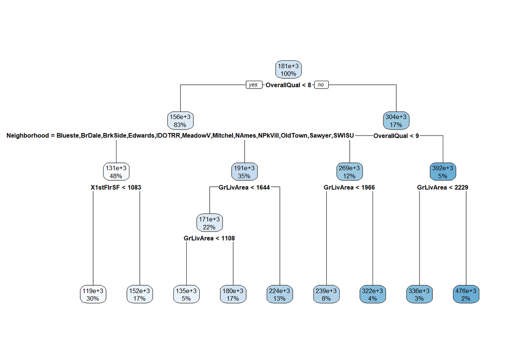

```r
arbol1 <- rpart(SalePrice ~ ., data=training)
rpart.plot(arbol1)
```

##Pregunta 3. Preddición del resultado

```r
pred1 <- predict(arbol1, data = training1)
p1 <- sum((training1$SalePrice - mean(training1$SalePrice)) ^ 2)
p2 <- sum((pred1 - training1$SalePrice) ^ 2)
p3 <- (p2 / p1)-1
p3
```

[output not shown]

Predijo el resultado con un error del 2% lo cuál no es malo pero puede mejorar, y lo hizo con una longitud de 4 por lo que debería de intentar con mayor longitud para ver si la prección mejora y cambia. Basandonos en el R^2 observamos que es bastante aceptable ya que es es bastante cercano a 1 por lo que se deduce que es un modelo de predicción bastante bueno.

##Pregunta 4. Arbol de regresión con todas las variables

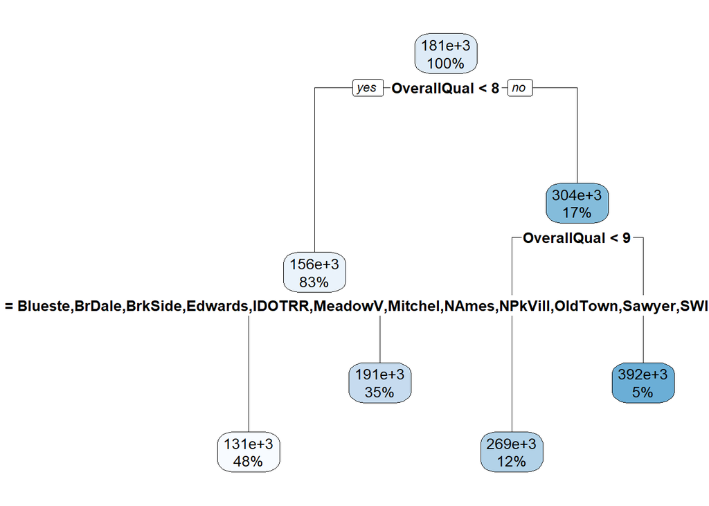

```r
modelo1 <- rpart(SalePrice ~ ., data=training, maxdepth=2)
modelo2 <- rpart(SalePrice ~ ., data=training, maxdepth=3)
modelo3 <- rpart(SalePrice ~ ., data=training, maxdepth=4)
rpart.plot(modelo1)
```

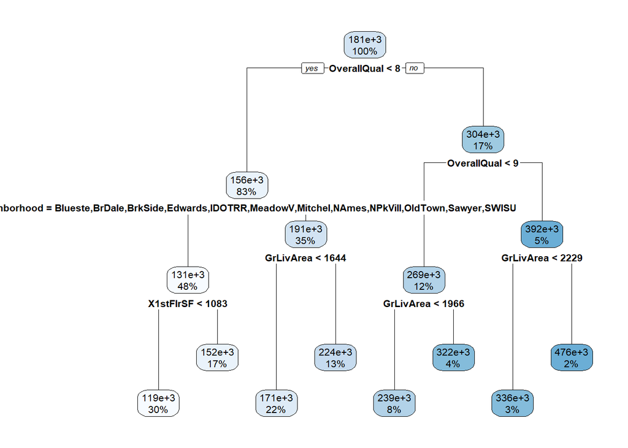

```r
rpart.plot(modelo2)
```

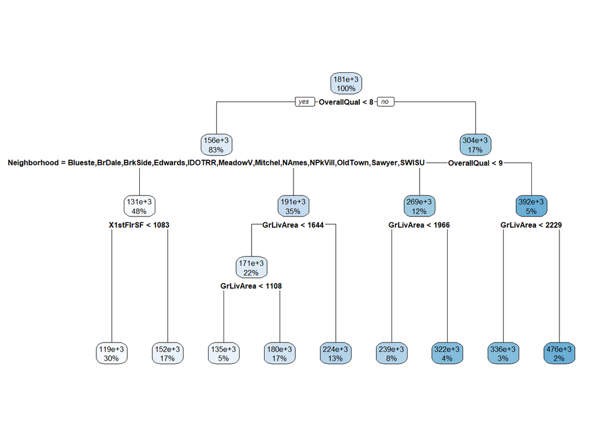

```r
rpart.plot(modelo3)
```

##Pregunta 5. Compare resultados Observamos como el arbol con longitud 6 es de 4 por lo que se indica que es la longitud maxima y por lo tanto la máxima predicción y minimo error es del 2%, esta de igual forma es mejor que la de longitud 2 con 5% y la de longitud 3 que aunque sea en menor porcentaje 2% en las otras predicciones de igual forma tiene mayores porcentajes que la de longitud 6.

## Pregunta 6. Economica, intermedia o cara

```r
training1$clasification <- ifelse(training1$SalePrice > 214000, "Caras", ifelse(training1$SalePrice>163000, "Intemedia", "Economicas"))
table(training1$clasification)
```

```
##
##      Caras Economicas  Intemedia
##        252        518        251
```

Los limites de como clasificar fueron basados en el analisis exploratorio de los datos de la hoja pasada en donde tomas el 1er y 3er cuartil y la media de la variable SalePrice.

## Pregunta 7. Elabore un árbol de clasificación utilizando la variable respuesta que creó en el punto anterior. Explique los resultados a los que llega. Muestre el modelo gráficamente. Recuerde que la nueva variable respuesta es categórica, pero se generó a partir de los precios de las casas, no incluya el precio de venta para entrenar el modelo.

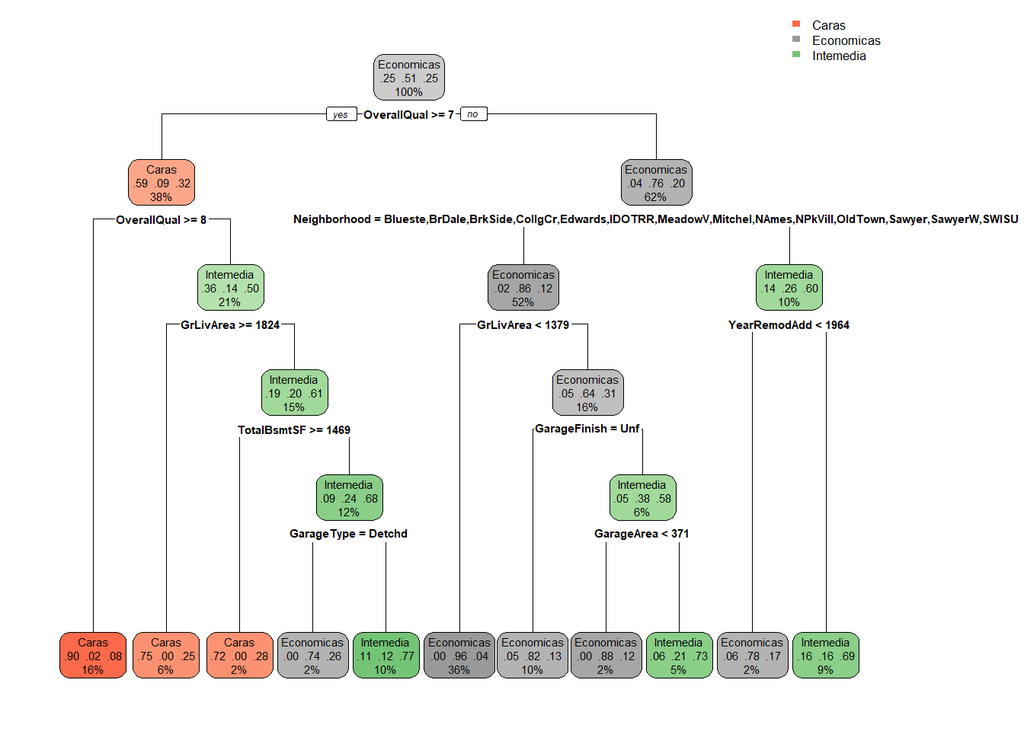

```r
training1<-training1[,-81]
modclasificacion<-rpart(clasification~.,data = training1,method = "class")
rpart.plot(modclasificacion)
```

## Pregunta 8.Utilice el modelo con el conjunto de prueba y determine la eficiencia del algoritmo para clasificar

```r
y <- ifelse(test1$SalePrice > 214000, "Caras", ifelse(test1$SalePrice>163000, "Intemedia", "Economicas"))
test1 <- test1[,-81]
y <- as.factor(y)

pred2<-predict(modclasificacion, newdata = test1[,-81])
pred2 <- apply(pred2, 1, function(x) colnames(pred2)[which.max(x)])
pred2 <- factor(pred2)
```

Podemos observar en las siguientes tablas que el error que se tuvo en la predicción de casas catalogadas como caras fue de un excedente de 2, para la predicción de casas economicas fue de un exceso 11 y para las casas intermedias fue de una falta de 13 casas. Presentado como porcentajes de error, Se tuvo 1.81% de error en las casas caras, un error de 5.14% para las economicas y un error de 11.30% para las casas de clasificación intermedia. De igual manera se puede observar la similaridad en los gráficos siguientes.

### Tabla valores reales de clasificación

```r
table(y)
```

```
## y
##      Caras Economicas  Intemedia
##        110        214        115
```

### Tabla valores predecidos de clasificación

```r
table(pred2)
```

```
## pred2
##      Caras Economicas  Intemedia
##        112        225        102
```

Grafico de datos de predicción

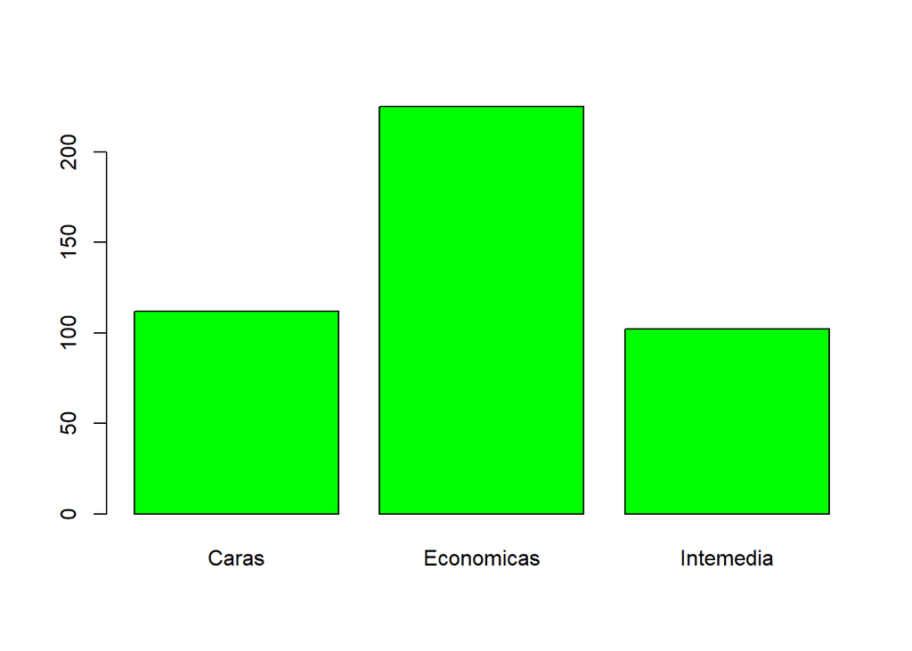

```r
plot(pred2, col="green",density=20,angle=135+geom_text(aes(label = signif(pred2)), nudge_y = 0))
```

Gráfico de valores reales

[figure not shown]

```r
plot(y , col="blue",density=20,angle=135)
```

## PRoblema 9. Haga un análisis de la eficiencia del algoritmo usando una matriz de confusión para el árbol de clasificación. Tenga en cuenta la efectividad, donde el algoritmo se equivocó más, donde se equivocó menos y la importancia que tienen los errores.

A partir de los datos obtenidos con la matriz de confusión tenemos una precision de 80.41% en los datos, de los cuales la tabla nos indica que se equivocó en 33 predicciones para la clasificacion de casas intermedias, se equivocó en 28 predicciones para la clasificación de casas económicas y se equivocó en 25 predicciones para la clasificación de casas caras. Podemos notar que el algoritmo se equivocó más en la prediccion de clasificación intermedia, y se equivocó menos en la clasificación de casas caras. Nuestro modelo es 80% efectivo sobre los datos, los errores que se tienen pueden ser respecto a los datos que estaban más cerca de los limites de separación para la clasificación.

```r
confusionMatrix(y, pred2)
```

```
## Confusion Matrix and Statistics
##
##             Reference
## Prediction   Caras Economicas Intemedia
##   Caras         87          4        19
##   Economicas     3        197        14
##   Intemedia     22         24        69
##
## Overall Statistics
##
##                Accuracy : 0.8041
##                  95% CI : (0.7638, 0.8402)
##     No Information Rate : 0.5125
##     P-Value [Acc > NIR] : <2e-16
##
##                   Kappa : 0.6867
##
##  Mcnemar's Test P-Value : 0.3926
##
## Statistics by Class:
##
##                      Class: Caras Class: Economicas Class: Intemedia
## Sensitivity                0.7768            0.8756           0.6765
## Specificity                0.9297            0.9206           0.8635
## Pos Pred Value             0.7909            0.9206           0.6000
## Neg Pred Value             0.9240            0.8756           0.8981
## Prevalence                 0.2551            0.5125           0.2323
## Detection Rate             0.1982            0.4487           0.1572
## Detection Prevalence       0.2506            0.4875           0.2620
## Balanced Accuracy          0.8532            0.8981           0.7700
```

## Pregunta 10 Entrene un modelo usando validación cruzada, prediga con él. ¿le fue mejor que al modelo anterior?

```
## CART
##
## 1121 samples
##   37 predictor
##  570 classes: '35311', '40000', '55993', '58500', '60000', '62383', '64500', '66500', '67000', '68400', '68500', '73000', '75000', '76000', '78000', '79000', '79500', '79900', '80000', '81000', '82000', '82500', '83000', '84900', '85000', '85400', '86000', '87000', '88000', '89000', '89471', '895…
##
## No pre-processing
## Resampling: Cross-Validated (10 fold, repeated 2 times)
## Summary of sample sizes: 999, 1011, 996, 1002, 1025, 1011, ...
## Resampling results:
##
##   Accuracy  Kappa
##   0.010182  0.005572163
##
## Tuning parameter 'cp' was held constant at a value of 0.001
```

## Pregunta 11, realizar diferentes arboles.

### Profundidad 4

```
## CART
##
## 1121 samples
##   37 predictor
##  570 classes: '35311', '40000', '55993', '58500', '60000', '62383', '64500', '66500', '67000', '68400', '68500', '73000', '75000', '76000', '78000', '79000', '79500', '79900', '80000', '81000', '82000', '82500', '83000', '84900', '85000', '85400', '86000', '87000', '88000', '89000', '89471', '895…
##
## No pre-processing
## Resampling: Cross-Validated (10 fold, repeated 2 times)
## Summary of sample sizes: 1020, 1008, 1020, 1009, 1002, 986, ...
## Resampling results:
##
##   Accuracy     Kappa
##   0.009936746  0.005528953
##
## Tuning parameter 'cp' was held constant at a value of 0.001
```

### Profundidad 5

```
## CART
##
## 1121 samples
##   37 predictor
##  570 classes: '35311', '40000', '55993', '58500', '60000', '62383', '64500', '66500', '67000', '68400', '68500', '73000', '75000', '76000', '78000', '79000', '79500', '79900', '80000', '81000', '82000', '82500', '83000', '84900', '85000', '85400', '86000', '87000', '88000', '89000', '89471', '895…
##
## No pre-processing
## Resampling: Cross-Validated (10 fold, repeated 2 times)
## Summary of sample sizes: 1000, 1017, 1010, 1031, 996, 1009, ...
## Resampling results:
##
##   Accuracy    Kappa
##   0.01229253  0.007701553
##
## Tuning parameter 'cp' was held constant at a value of 0.001
```

### Profundidad 6

```
## CART
##
## 1121 samples
##   37 predictor
##  570 classes: '35311', '40000', '55993', '58500', '60000', '62383', '64500', '66500', '67000', '68400', '68500', '73000', '75000', '76000', '78000', '79000', '79500', '79900', '80000', '81000', '82000', '82500', '83000', '84900', '85000', '85400', '86000', '87000', '88000', '89000', '89471', '895…
##
## No pre-processing
## Resampling: Cross-Validated (10 fold, repeated 2 times)
## Summary of sample sizes: 999, 1034, 1000, 1015, 1008, 991, ...
## Resampling results:
##
##   Accuracy    Kappa
##   0.01155462  0.006957861
##
## Tuning parameter 'cp' was held constant at a value of 0.001
```

Comparando los tres modelos podemos notar que el más preciso es el que tiene profundidad 5, validando lo antes propuesto.

## Pregunta 12 Repita los análisis usando random forest como algoritmo de predicción, explique sus resultados comparando ambos algoritmos.

[output not shown]

[output cut: 110 more lines]